# Framingham Heart Study Using Logistic Regression

ECON145 Instructor

26 September, 2024

# 1 Loading and Exploring the Data Set

Let’s first read the data set from the file.

```r
framingham = read.csv("Framingham.csv")
str(framingham)
```

```
## 'data.frame':    4240 obs. of  16 variables:
##  $ male           : int  1 0 1 0 0 0 0 0 1 1 ...
##  $ age            : int  39 46 48 61 46 43 63 45 52 43 ...
##  $ education      : int  4 2 1 3 3 2 1 2 1 1 ...
##  $ currentSmoker  : int  0 0 1 1 1 0 0 1 0 1 ...
##  $ cigsPerDay     : int  0 0 20 30 23 0 0 20 0 30 ...
##  $ BPMeds         : int  0 0 0 0 0 0 0 0 0 0 ...
##  $ prevalentStroke: int  0 0 0 0 0 0 0 0 0 0 ...
##  $ prevalentHyp   : int  0 0 0 1 0 1 0 0 1 1 ...
##  $ diabetes       : int  0 0 0 0 0 0 0 0 0 0 ...
##  $ totChol        : int  195 250 245 225 285 228 205 313 260 225 ...
##  $ sysBP          : num  106 121 128 150 130 ...
##  $ diaBP          : num  70 81 80 95 84 110 71 71 89 107 ...
##  $ BMI            : num  27 28.7 25.3 28.6 23.1 ...
##  $ heartRate      : int  80 95 75 65 85 77 60 79 76 93 ...
##  $ glucose        : int  77 76 70 103 85 99 85 78 79 88 ...
##  $ TenYearCHD     : int  0 0 0 1 0 0 1 0 0 0 ...
```

As we have learned before, we should convert the categorical variables to the “Factor” type in R.

```r
framingham$male = as.factor(framingham$male)
framingham[,3:4] = lapply(framingham[,3:4], as.factor)
framingham[,6:9] = lapply(framingham[,6:9], as.factor)
str(framingham)
```

```
## 'data.frame':    4240 obs. of  16 variables:
##  $ male           : Factor w/ 2 levels "0","1": 2 1 2 1 1 1 1 1 2 2 ...
##  $ age            : int  39 46 48 61 46 43 63 45 52 43 ...
##  $ education      : Factor w/ 4 levels "1","2","3","4": 4 2 1 3 3 2 1 2 1 1 ...
##  $ currentSmoker  : Factor w/ 2 levels "0","1": 1 1 2 2 2 1 1 2 1 2 ...
##  $ cigsPerDay     : int  0 0 20 30 23 0 0 20 0 30 ...
##  $ BPMeds         : Factor w/ 2 levels "0","1": 1 1 1 1 1 1 1 1 1 1 ...
##  $ prevalentStroke: Factor w/ 2 levels "0","1": 1 1 1 1 1 1 1 1 1 1 ...
##  $ prevalentHyp   : Factor w/ 2 levels "0","1": 1 1 1 2 1 2 1 1 2 2 ...
##  $ diabetes       : Factor w/ 2 levels "0","1": 1 1 1 1 1 1 1 1 1 1 ...
##  $ totChol        : int  195 250 245 225 285 228 205 313 260 225 ...
##  $ sysBP          : num  106 121 128 150 130 ...
##  $ diaBP          : num  70 81 80 95 84 110 71 71 89 107 ...
##  $ BMI            : num  27 28.7 25.3 28.6 23.1 ...
##  $ heartRate      : int  80 95 75 65 85 77 60 79 76 93 ...
##  $ glucose        : int  77 76 70 103 85 99 85 78 79 88 ...
##  $ TenYearCHD     : int  0 0 0 1 0 0 1 0 0 0 ...
```

Note that we have not yet converted the dependent variable, *TenYearCHD*, into the “Factor” type. We will first revisit the results from linear regression and then compare them with those from logistic regression.

Let’s first check the percentage of missing values in each variable.

```r
sapply(framingham, function(x) 100*sum(is.na(x))/nrow(framingham))
```

```
##            male             age       education   currentSmoker      cigsPerDay
##      0.00000000      0.00000000      2.47641509      0.00000000      0.68396226
##          BPMeds prevalentStroke    prevalentHyp        diabetes         totChol
##      1.25000000      0.00000000      0.00000000      0.00000000      1.17924528
##           sysBP           diaBP             BMI       heartRate         glucose
##      0.00000000      0.00000000      0.44811321      0.02358491      9.15094340
##      TenYearCHD
##      0.00000000
```

For this class demonstration, let’s delete those observations with missing values. In practice, we must be careful in handling missing values.

```r
framingham = na.omit(framingham)
str(framingham)
```

```
## 'data.frame':    3658 obs. of  16 variables:
##  $ male           : Factor w/ 2 levels "0","1": 2 1 2 1 1 1 1 1 2 2 ...
##  $ age            : int  39 46 48 61 46 43 63 45 52 43 ...
##  $ education      : Factor w/ 4 levels "1","2","3","4": 4 2 1 3 3 2 1 2 1 1 ...
##  $ currentSmoker  : Factor w/ 2 levels "0","1": 1 1 2 2 2 1 1 2 1 2 ...
##  $ cigsPerDay     : int  0 0 20 30 23 0 0 20 0 30 ...
##  $ BPMeds         : Factor w/ 2 levels "0","1": 1 1 1 1 1 1 1 1 1 1 ...
##  $ prevalentStroke: Factor w/ 2 levels "0","1": 1 1 1 1 1 1 1 1 1 1 ...
##  $ prevalentHyp   : Factor w/ 2 levels "0","1": 1 1 1 2 1 2 1 1 2 2 ...
##  $ diabetes       : Factor w/ 2 levels "0","1": 1 1 1 1 1 1 1 1 1 1 ...
##  $ totChol        : int  195 250 245 225 285 228 205 313 260 225 ...
##  $ sysBP          : num  106 121 128 150 130 ...
##  $ diaBP          : num  70 81 80 95 84 110 71 71 89 107 ...
##  $ BMI            : num  27 28.7 25.3 28.6 23.1 ...
##  $ heartRate      : int  80 95 75 65 85 77 60 79 76 93 ...
##  $ glucose        : int  77 76 70 103 85 99 85 78 79 88 ...
##  $ TenYearCHD     : int  0 0 0 1 0 0 1 0 0 0 ...
##  - attr(*, "na.action")= 'omit' Named int [1:582] 15 22 27 34 37 43 50 55 71 73 ...
##   ..- attr(*, "names")= chr [1:582] "15" "22" "27" "34" ...
```

We can see how many individuals developed coronary heart disease (CHD) in ten years and how many individuals did not by using the ‘table’ function.

```r
table(framingham$TenYearCHD)
```

```
##
##    0    1
## 3101  557
```

The percentage of individuals who developed CHD in ten years can be computed as follows.

```r
percCHD = sum(framingham$TenYearCHD)/nrow(framingham)
percCHD
```

```
## [1] 0.152269
```

# 2 Splitting the Data Set for Training and Testing

```r
library(caTools)
```

Now, let’s use this package to randomly split our data into a training set and a test set. We will do this by using a function called ‘sample.split’, which is part of the “caTools” package. Since this function randomly splits your data, it could split it differently for each of us. To make sure that we all get the same split, we can set our seed to the same number.

```r
set.seed(100)
split = sample.split(framingham$TenYearCHD, SplitRatio = 0.70)
split[1:20]
```

```
##  [1]  TRUE  TRUE  TRUE  TRUE  TRUE  TRUE  TRUE  TRUE FALSE  TRUE  TRUE  TRUE
## [13]  TRUE FALSE  TRUE  TRUE FALSE  TRUE FALSE  TRUE
```

The first argument in the ‘sample.split’ function makes sure that in the training set, around 15.23% of the individuals developed CHD in ten years, and in the test set 15.23% of the individuals developed CHD in ten years. In other words, the *TenYearCHD* variable is balanced in training and test sets. We want to do this so that our test set is representative of the training set.

The split function creates a TRUE or FALSE value for each of our observations. TRUE means that we should put that observation in the training set, and FALSE means that we should put that observation in the test set. Now let’s create our training and test sets using the ‘subset’ function.

```r
framinghamTrain = subset(framingham, split == TRUE)
framinghamTest = subset(framingham, split == FALSE)
```

We can check the number of data points in the training set and the test set, and confirm that the fractions of individuals who developed CHD in ten years are indeed similar to the whole dataset.

```r
table(framinghamTrain$TenYearCHD)
```

```
##
##    0    1
## 2171  390
```

```r
sum(framinghamTrain$TenYearCHD)/nrow(framinghamTrain)
```

```
## [1] 0.1522843
```

```r
table(framinghamTest$TenYearCHD)
```

```
##
##   0   1
## 930 167
```

```r
sum(framinghamTest$TenYearCHD)/nrow(framinghamTest)
```

```
## [1] 0.1522334
```

# 3 Building Linear Regression Models

Recall the linear regression model of using all the independent variables.

```r
linModel = lm(TenYearCHD ~ ., data = framinghamTrain)
summary(linModel)
```

```
##
## Call:
## lm(formula = TenYearCHD ~ ., data = framinghamTrain)
##
## Residuals:
##      Min       1Q   Median       3Q      Max
## -0.71221 -0.18536 -0.10551 -0.01096  1.07341
##
## Coefficients:
##                    Estimate Std. Error t value Pr(>|t|)
## (Intercept)      -0.5585219  0.0938940  -5.948 3.08e-09 ***
## male1             0.0519583  0.0150741   3.447 0.000576 ***
## age               0.0070251  0.0009309   7.546 6.20e-14 ***
## education2       -0.0139725  0.0166636  -0.839 0.401827
## education3       -0.0254858  0.0200981  -1.268 0.204889
## education4       -0.0133774  0.0231004  -0.579 0.562574
## currentSmoker1    0.0151090  0.0218574   0.691 0.489470
## cigsPerDay        0.0023370  0.0009415   2.482 0.013117 *
## BPMeds1           0.0701339  0.0410007   1.711 0.087286 .
## prevalentStroke1  0.0484975  0.1091493   0.444 0.656847
## prevalentHyp1     0.0190762  0.0208096   0.917 0.359385
## diabetes1         0.0350311  0.0526092   0.666 0.505552
## totChol           0.0001340  0.0001613   0.831 0.406264
## sysBP             0.0028345  0.0005972   4.746 2.19e-06 ***
## diaBP            -0.0019303  0.0009734  -1.983 0.047475 *
## BMI               0.0002581  0.0018647   0.138 0.889910
## heartRate        -0.0004165  0.0005931  -0.702 0.482646
## glucose           0.0010791  0.0003444   3.133 0.001748 **
## ---
## Signif. codes:  0 '***' 0.001 '**' 0.01 '*' 0.05 '.' 0.1 ' ' 1
##
## Residual standard error: 0.3416 on 2543 degrees of freedom
## Multiple R-squared:  0.1027, Adjusted R-squared:  0.09668
## F-statistic: 17.12 on 17 and 2543 DF,  p-value: < 2.2e-16
```

From the above report, we can observe a list of variables that are significant in terms of predicting the risk of developing CHD in ten years.

# 4 Building Logistic Regression Models

Similar to building the above linear regression model, let’s now build a logistic regression model using all the variables in the data set other than the dependent variable as independent variables. Before that, we need to convert the dependent variable into the “Factor” type to avoid some issues in the analysis later. In the code below, we use the function, ‘glm’, which stands for generalized linear model. The argument, *family = binomial*, indicates that we are trying to predict two possible outcomes so that the logistic regression model will be called from the class of generalized linear models.

```r
framinghamTrain$TenYearCHD = as.factor(framinghamTrain$TenYearCHD)
logModel1 = glm(TenYearCHD ~ ., data = framinghamTrain, family = "binomial")
summary(logModel1)
```

```
##
## Call:
## glm(formula = TenYearCHD ~ ., family = "binomial", data = framinghamTrain)
##
## Coefficients:
##                   Estimate Std. Error z value Pr(>|z|)
## (Intercept)      -8.205609   0.848219  -9.674  < 2e-16 ***
## male1             0.497280   0.131930   3.769 0.000164 ***
## age               0.063948   0.008122   7.874 3.45e-15 ***
## education2       -0.112110   0.145016  -0.773 0.439474
## education3       -0.232291   0.183097  -1.269 0.204556
## education4       -0.111357   0.202087  -0.551 0.581609
## currentSmoker1    0.160592   0.187927   0.855 0.392803
## cigsPerDay        0.018589   0.007457   2.493 0.012671 *
## BPMeds1           0.307977   0.275670   1.117 0.263913
## prevalentStroke1  0.265385   0.726877   0.365 0.715034
## prevalentHyp1     0.159858   0.166183   0.962 0.336079
## diabetes1         0.100131   0.368270   0.272 0.785703
## totChol           0.002240   0.001327   1.689 0.091303 .
## sysBP             0.017890   0.004585   3.902 9.54e-05 ***
## diaBP            -0.009700   0.007648  -1.268 0.204664
## BMI               0.009286   0.015385   0.604 0.546138
## heartRate        -0.003539   0.005054  -0.700 0.483783
## glucose           0.006358   0.002506   2.537 0.011179 *
## ---
## Signif. codes:  0 '***' 0.001 '**' 0.01 '*' 0.05 '.' 0.1 ' ' 1
##
## (Dispersion parameter for binomial family taken to be 1)
##
##     Null deviance: 2185.3  on 2560  degrees of freedom
## Residual deviance: 1926.9  on 2543  degrees of freedom
## AIC: 1962.9
##
## Number of Fisher Scoring iterations: 5
```

The model output is also similar to a linear regression model. The AIC value is a measure of the quality of the model and is like the adjusted R-squared in that it accounts for the number of variables used compared to the number of observations. It provides a means for model selection, but one can only use it to compare models built on the same data set. The preferred model is the one with the minimum AIC. The last line has to do with the algorithm (Newton-Raphson algorithm or Newton’s Method by default) that is used to find the coefficients (through solving an optimization problem). This information on AIC and algorithm will not be tested.

We can observe that the logistic regression model reveals almost the same set of significant independent variables with slight differences in significance levels, which is typically the case (not theoretically guaranteed).

1. Understanding the results: Apart from the significance of the effects estimates given by the `glm` model-fitting process, we can also compute the Odds Ratios and the corresponding 95% CI. This will provide better explanability of the results.

```r
# Calculate Odds
odds <- exp(coef(logModel1))

# Calculate 95% Confidence Intervals for Odds Ratios
conf_int <- exp(confint(logModel1))
# `confint()` function by default performs a profile likelihood calculation which can be time-consuming, especially for models with many predictors or large datasets. A quicker way is toapproximate the confidence intervals using the standard errors from the coefficients as follows:
se <- sqrt(diag(vcov(logModel1)))

lower_limits <- odds * exp(-1.96 * se)
upper_limits <- odds * exp(1.96 * se)

# Combine Odds Ratios and Confidence Intervals into a dataframe
Odds_df_approx <- data.frame(Odds = odds, LowerCI = lower_limits, UpperCI = upper_limits)
```

2. We can further refine the model by only including the significant effects befor testing the model with the `Test` data set. Let’s construct another logistic regression model using only independent variables that are significant at the 0.1 level from the above model. This is known as **Stepwise Regression**.

```r
logModel2 = glm(TenYearCHD ~ male + age + cigsPerDay + totChol + sysBP + glucose, data = framinghamTrain, family = "binomial")
summary(logModel2)
```

```
##
## Call:
## glm(formula = TenYearCHD ~ male + age + cigsPerDay + totChol +
##     sysBP + glucose, family = "binomial", data = framinghamTrain)
##
## Coefficients:
##              Estimate Std. Error z value Pr(>|z|)
## (Intercept) -9.091277   0.561256 -16.198  < 2e-16 ***
## male1        0.495312   0.127728   3.878 0.000105 ***
## age          0.067888   0.007737   8.775  < 2e-16 ***
## cigsPerDay   0.022641   0.004971   4.554 5.25e-06 ***
## totChol      0.002181   0.001319   1.653 0.098364 .
## sysBP        0.016934   0.002542   6.661 2.73e-11 ***
## glucose      0.006680   0.001926   3.469 0.000523 ***
## ---
## Signif. codes:  0 '***' 0.001 '**' 0.01 '*' 0.05 '.' 0.1 ' ' 1
##
## (Dispersion parameter for binomial family taken to be 1)
##
##     Null deviance: 2185.3  on 2560  degrees of freedom
## Residual deviance: 1934.2  on 2554  degrees of freedom
## AIC: 1948.2
##
## Number of Fisher Scoring iterations: 5
```

# 5 In-Sample Model Performance

## 5.1 Sensitivity and Specificity

We can now make predictions on the **training set**. The argument *type = “response”* in the code below makes sure that the algorithm uses the logistic response function to compute the predictions, which should be numbers between 0 and 1. You can try removing this argument and see what you get.

```r
predictTrain = predict(logModel2, type = "response")
summary(predictTrain)
```

```
##    Min. 1st Qu.  Median    Mean 3rd Qu.    Max.
## 0.01493 0.06541 0.11865 0.15228 0.20120 0.92057
```

Let’s take a look at the predicted probabilities of developing CHD in ten years for the first ten individuals in the training set, and compare them to the actual observations.

```r
predictTrain[1:10]
```

```
##          1          2          3          4          5          6          7
## 0.03865006 0.05382850 0.15140594 0.36536664 0.11334434 0.12286854 0.18806070
##          8         10         11
## 0.06377181 0.23580595 0.08446739
```

```r
framinghamTrain$TenYearCHD[1:10]
```

```
##  [1] 0 0 0 1 0 0 1 0 0 0
## Levels: 0 1
```

Note that the indices in the display of the first ten elements in *predictTrain* correspond to the indices of individuals in the original data frame before random splitting into the training and test sets. You can confirm this by referring the output from displaying *split* in the above code chunk.

Let’s see if the model is predicting higher probabilities for the actual CHD cases as we expect.

```r
tapply(predictTrain, framinghamTrain$TenYearCHD, mean)
```

```
##         0         1
## 0.1355687 0.2453342
```

If we use 0.5 as the threshold, we get the following confusion matrix.

```r
conf05 = table(framinghamTrain$TenYearCHD, predictTrain > 0.5)
conf05
```

```
##
##     FALSE TRUE
##   0  2158   13
##   1   358   32
```

We can calculate the Sensitivity and Specificity.

```r
TN <- conf05[1, 1]
FP <- conf05[1, 2]
TP <- conf05[2, 2]
FN <- conf05[2, 1]

specificity <- TN / (TN + FP)
sensitivity <- TP / (TP + FN)

# cat to concatenate text and variables in R
cat("Specificity:", specificity, "\n")
```

```
## Specificity: 0.994012
```

```r
cat("Sensitivity:", sensitivity)
```

```
## Sensitivity: 0.08205128
```

We can see that for 2158 cases, we predict no CHD, and they did not develop CHD; and for 32 cases, we predict CHD, and they developed CHD. We make 13 mistakes where we say CHD, and we make 358 mistakes where we say no CHD. The accuracy of the prediction using 0.5 as the threshold is 2190/2561 = 85.51%.

We can compute the sensitivity, or the true positive rate, which equals to 32/390 = 0.08, and the specificity, or the true negative rate, which equals to 2158/2171 = 0.99.

Let’s try increasing the threshold to 0.7.

```r
conf07 = table(framinghamTrain$TenYearCHD, predictTrain > 0.7)
conf07
```

```
##
##     FALSE TRUE
##   0  2170    1
##   1   386    4
```

```r
conf02 = table(framinghamTrain$TenYearCHD, predictTrain > 0.3)
conf02
```

```
##
##     FALSE TRUE
##   0  1998  173
##   1   279  111
```

Now the sensitivity equals to 111/390 = 0.28 and the specificity equals to 1998/2171 = 0.92. By decreasing the threshold, our sensitivity goes up, and our specificity goes down.

## 5.2 Receiver Operating Characteristic (ROC) Curves

To generate receiver operating characteristic (ROC) curves in R, we need to install a new package, called “ROCR.”

```r
library(ROCR)
```

Recall that we made predictions on our training set and called them *predictTrain*. We will use these predictions to create our ROC curve.

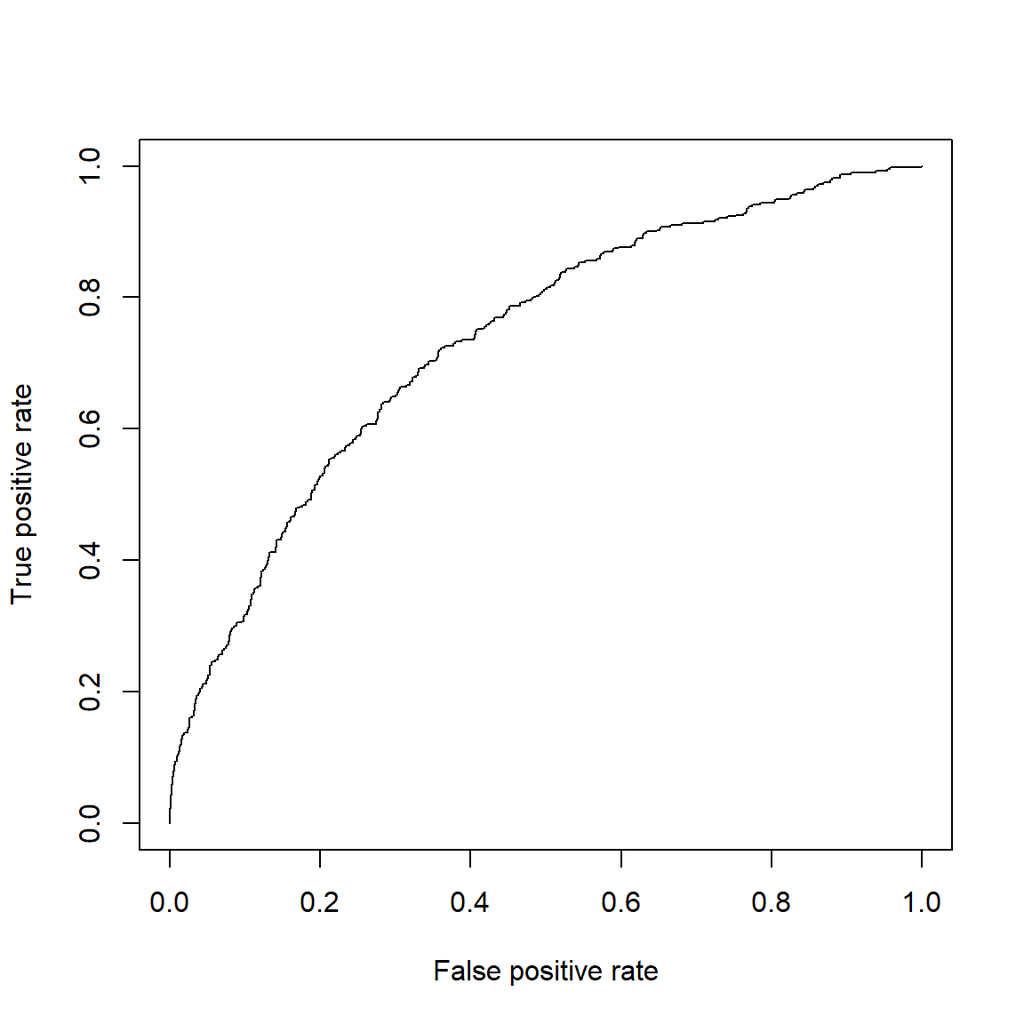

```r
ROCRpred = prediction(predictTrain, framinghamTrain$TenYearCHD)
ROCRperf = performance(ROCRpred, "tpr", "fpr")
plot(ROCRperf)
```

We can add more visual effects to the ROC plot.

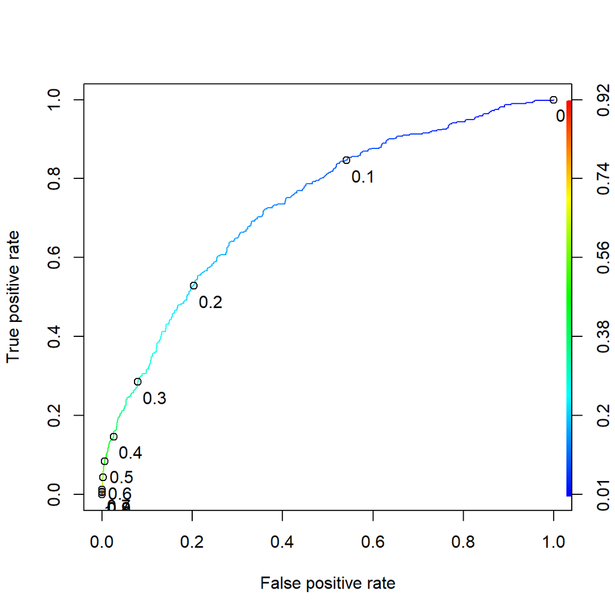

```r
plot(ROCRperf, colorize = TRUE, print.cutoffs.at = seq(0,1,0.1), text.adj = c(-0.2,1.7))
```

Now let’s compute the area under the ROC curve (AUROC), or simply AUC.

```r
ROCRauc = performance(ROCRpred, "auc")
ROCRauc@y.values
```

```
## [[1]]
## [1] 0.7349077
```

There are other packages available for plotting ROC, and they offer different features that may be useful in some situations. For example, if we want to color the area under the ROC curve, we can use the ‘plot.roc’ function in the “pROC” package. Remember to install this package before the first use.

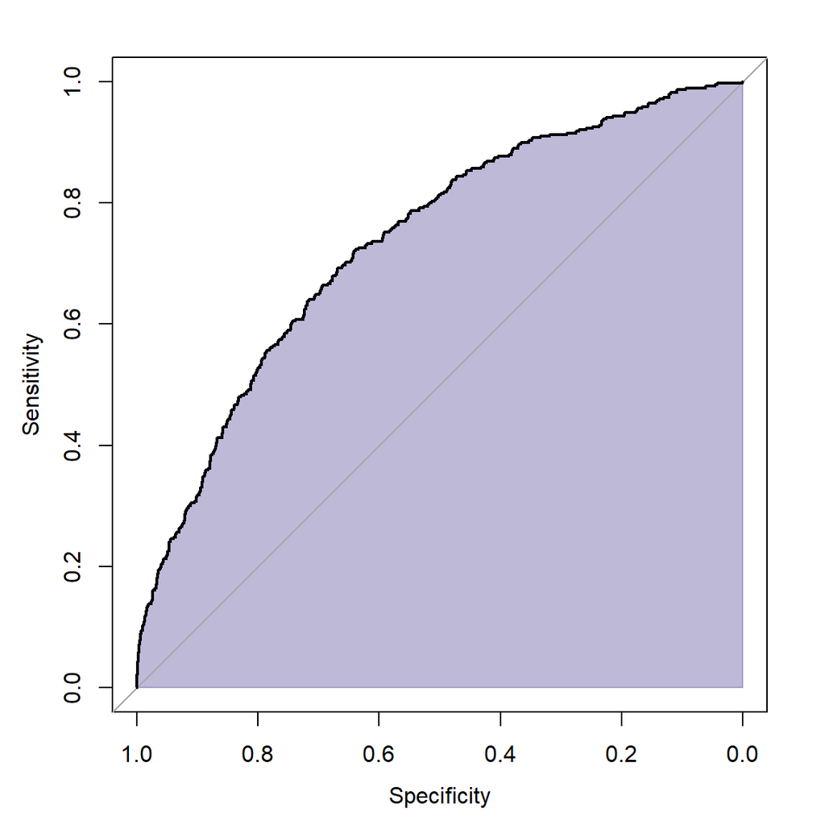

```r
library(pROC)
plot.roc(framinghamTrain$TenYearCHD, predictTrain,
    xlim=c(1,0),
    ylim=c(0,1),
    auc.polygon = TRUE,
    auc.polygon.col=rgb(.35,0.31,0.61, alpha = 0.4),
    auc.polygon.border=rgb(.35,0.31,0.61, 0.4))
```

Note that by default, the x-axis for the ‘plot.roc’ function is specificity, which equals (1 - false-positive rate), and the numbers go from 1 to 0 from left to right.

# 6 Out-of-Sample Model Performance

Similarly, we can perform the out-of-sample test for our model using the test data set.

```r
predictTest = predict(logModel2, type = "response", newdata = framinghamTest)
conf03out = table(framinghamTest$TenYearCHD, predictTest > 0.3)
conf03out
```

```
##
##     FALSE TRUE
##   0   853   77
##   1   126   41
```

The out-of-sample accuracy of the model with threshold 0.3 is 894/1097 = 81.49%. We can also plot the out-of-sample ROC of the model and compute its out-of-sample AUC.

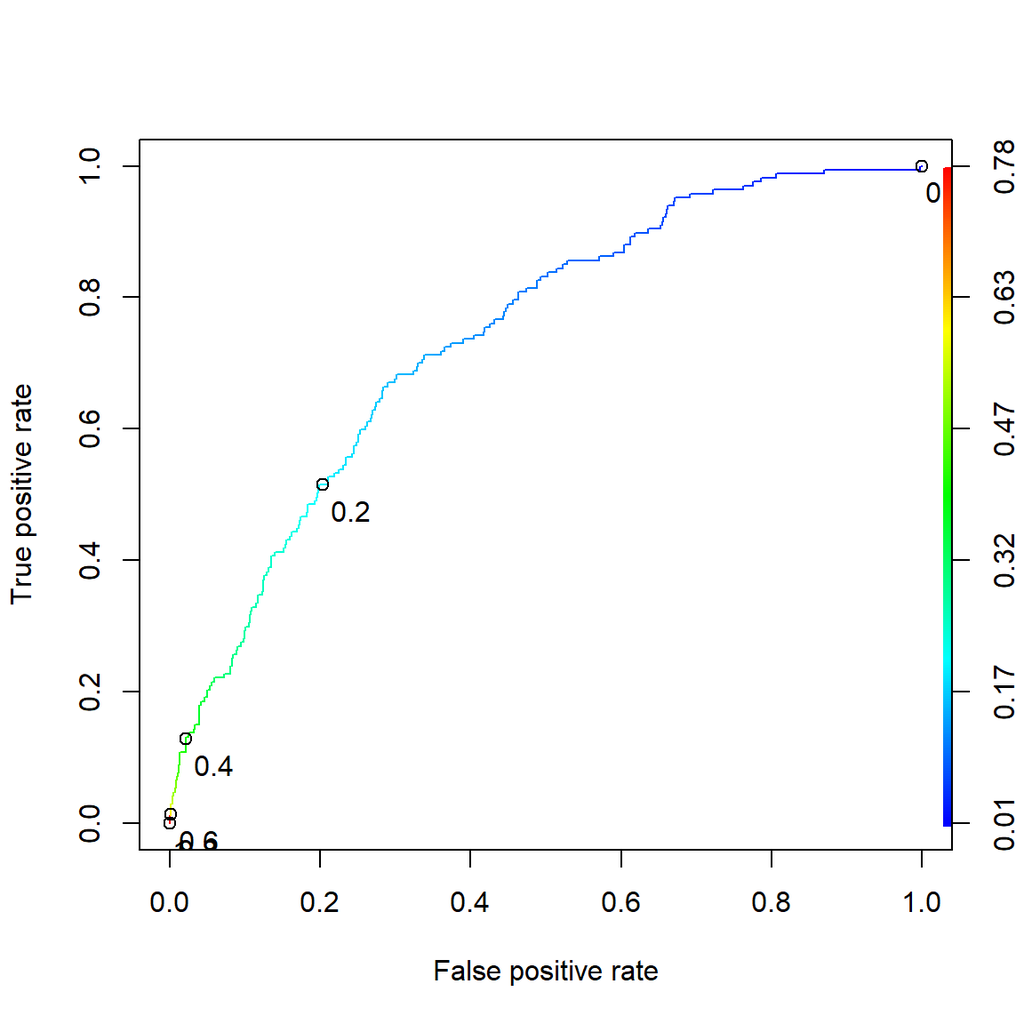

```r
ROCRpredTest <- prediction(predictTest, framinghamTest$TenYearCHD)
ROCRperfTest <- performance(ROCRpredTest, "tpr", "fpr")

plot(ROCRperfTest, colorize = TRUE, print.cutoffs.at = seq(0,1,0.2), text.adj = c(-0.2,1.7))
```

```r
ROCRperfAUC <- performance(ROCRpredTest, "auc")
cat("Area Under the Receiver Operating Curve (AUROC):", ROCRperfAUC@y.values[[1]], "\n")
```

```
## Area Under the Receiver Operating Curve (AUROC): 0.7395853
```

The out-of-sample AUC of our model is 0.7395853.

We can also plot the out-of-sample Precision-Recall Curve of the model and compute its out-of-sample AUPRC. The ROCR package can still be used. Instead of plotting the TPR against the FPR, we can plot `Precision` vs `Recall`. Again the `performance` function calculates the AUPRC automatically. Specify `prec` for precision and `rec` for recall.

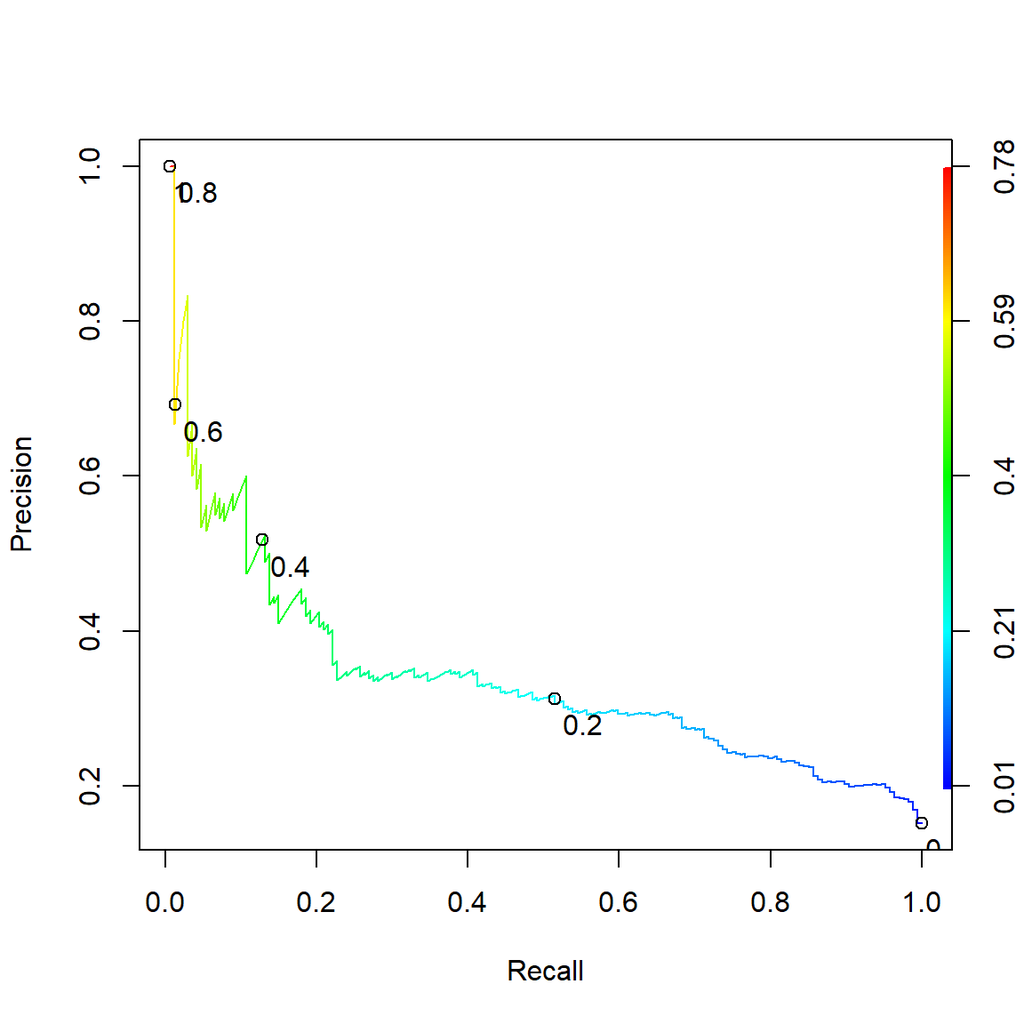

```r
ROCRperfPR <- performance(ROCRpredTest, "prec", "rec")
plot(ROCRperfPR, colorize = TRUE, print.cutoffs.at = seq(0,1,0.2), text.adj = c(-0.2,1.7))
```

```r
ROCRperfAUC <- performance(ROCRpredTest, measure = "aucpr")
cat("Area Under the Precision-Recall Curve (AUPRC):", ROCRperfAUC@y.values[[1]], "\n")
```

```
## Area Under the Precision-Recall Curve (AUPRC): 0.3457595
```

The out-of-sample AUPRC of our model is 0.3457595. This is much worse than the AUROC due to the imbalanced nature of the dataset where the proportion of positive cases is 0.1522843.